# In the pursuit of happiness

## Introduction

Our project today is to determine what socio-economic variables have statistically significant effects on a country’s level of happiness. We intend to do this through different types of regression models, applied to a dataset of 241 countries in 2014.

```r
df=readRDS("./merged_gapminder_happiness.rds")
df_variables=df%>%dplyr::select(-country,-year)
```

## Exploratory Data Analysis

#### Target variable

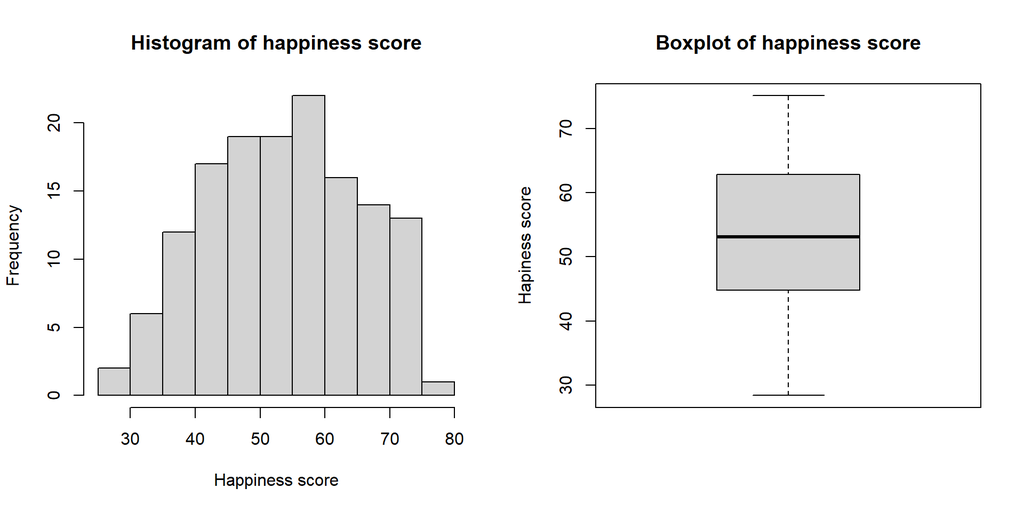

```
##    Min. 1st Qu.  Median    Mean 3rd Qu.    Max.
##   28.40   44.80   53.10   53.82   62.80   75.10
```

#### Independent variables

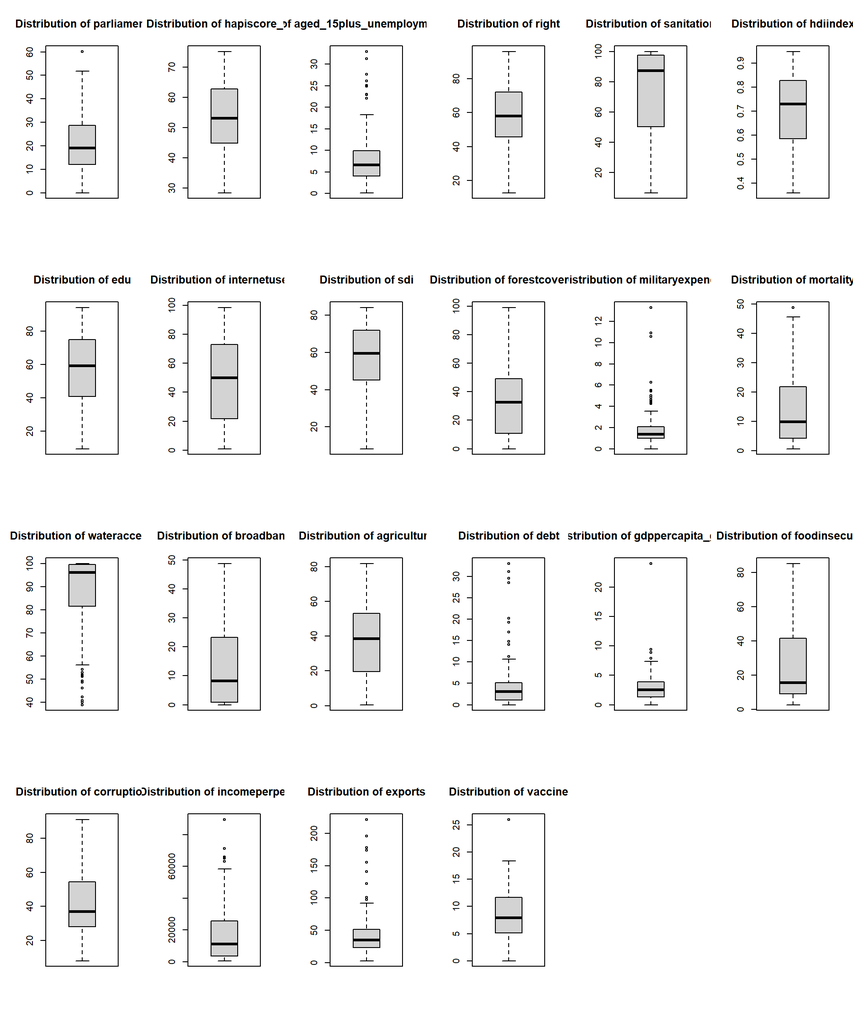

parliament: Percentage of national parliamentary seats held by women. Lower and upper houses combined.  
Distribution - skewed right, normal.

right: Fundamental Rights in the form of liberal and social rights support both fair representation and the vertical mechanism of accountability that the first attribute seeks to achieve. This attribute is composed of three subattributes: access to justice, civil liberties, and social rights and equality. The three subattributes were aggregated into the Fundamental Rights index using [BFA](https://www.idea.int/gsod-indices/sites/default/files/idea-gsodi-2019-codebook-v3.pdf)  
Distribution: normal/hump, wide spread  
IQR: 6.95000, variance: 7.135659e+01, standard deviation: 8.447283e+00

sanitation: percentage of people using improved sanitation facilities that are not shared with other households.  
distribution - uniform/linear then with sharp jump/exponential increase at 100%.  
IQR: 22.82500, variance: 1.784627e+02, standard deviation: 1.335899e+01

edu: Education index calculated based on Avg years of schooling, taking values 0 as minimum and 15 as maximum  
Distribution - wide spread.  
IQR: 12.12500, variance: 8.859174e+01, standard deviation: 9.412319e+00

internetusers: Percentage of Population with stable Internet access  
Distribution - multimodal, wide spread.  
IQR: 19.22500, variance: 2.372645e+02, standard deviation: 1.540339e+01

sdi: The Sustainable Development Index is an efficiency metric, designed to assess the ecological efficiency of nations in delivering human development. It is calculated as the quotient of two figures: (1) a “development index” based on the Human Development Index, calculated as the geometric mean of the life expectancy index, the education index, and a modified income index; and (2) an “ecological impact index” calculated as the extent to which consumption-based CO2 emissions and material footprint exceed per-capita shares of planetary boundaries.  
Distribution - seemingly linearly increasing, or skewed left.  
IQR: 5.17500, variance: 1.093839e+02, standard deviation: 1.045867e+01

forestcoverage: Percentage of total land area that has been covered with forest  
Distribution - Seemingly decreasing.  
IQR: 18.10500, variance: 3.058635e+02, standard deviation: 1.748895e+01

militaryexpenditure: Military expenditure as a percentage of GDP.  
Distribution - Right skewed normal with outliers at larger values.  
IQR: 0.78975, variance: 2.334034e+00, standard deviation: 1.527755e+00

mortality: Newborn mortality rate per 1000  
Distribution - decreasing  
IQR: 6.22500, variance: 1.591720e+01, standard deviation: 3.989636e+00

wateraccess: Percentage of people with at least basic water services  
Distribution - exponentially increasing.  
IQR: 7.25000, variance: 2.993909e+01, standard deviation: 5.471663e+00

broadband: Broadband subscribers per 100 people  
Distribution - steep drop/potentially exponentially decreasing.  
IQR: 9.98500, variance: 4.516839e+01, standard deviation: 6.720743e+00

agriculture: Percentage of land area that is arable  
Distribution - wide-ranging  
IQR: 13.02500, variance: 2.622336e+02, standard deviation: 1.619363e+01

debt: Total debt service (% of GNI)  
Distribution - Sharp decrease then flat  
IQR: 6.64000, variance: 3.385360e+01, standard deviation: 5.818385e+00

gdppercapita_growth: GDP per capita  
Distribution - decreasing with outliers  
IQR: 2.13000, variance: 2.543614e+00, standard deviation: 1.594871e+00

foodinsecurity: Prevalence of moderate or severe food insecurity in the population  
Distribution - normal skewed right  
IQR: 9.55000, variance: 1.128336e+02, standard deviation: 1.062232e+01

Exports:% of GNP: exports of goods & services, include the value of merchandise, freight, insurance, transport, travel  
Data source: https://data.worldbank.org/indicator/NE.EXP.GNFS.ZS\ IQR: 20.17500, variance: 2.426063e+02, standard deviation: 1.557582e+01

Corruption Perception Index (CPI): Transparency International’s score of perceptions of corruption. Higher value indicates less corruption.  
Data source: http://www.transparency.org/research/cpi\ IQR: 3.25000, variance: 8.818182e+00, standard deviation: 2.969542e+00

Income: Income per person adjusted for purchasing power  
Data Source: World Bank, http:llgapm.io/dgdppc\ IQR: 5350.00000, variance: 2.689152e+07, standard deviation: 5.185703e+03

Vaccine: Proportion of people who disagree that vaccines are effective for children to have  
Data Source: http://gapm.io/dvaccine_confidence\ IQR: 5.47500, variance: 3.927970e+01, standard deviation: 6.267352e+00

## General observations

There are some variables with significant left skew i.e beyond a certain threshold, the variable will most likely not affect the target variable any more (e.g water, sanitation). There are some variables with significant right skew i.e below a certain threshold, the variable will most likely not affect the target variable any more (e.g debt). There are a lot of variables with substantial numbers of missing values.

## knn imputation

From our summary, we find that foodsecurity,vaccine and aged_15plus_unemployment_rate_percent have a high number of missing variables. However, in general, our dataset contains very few full entries (12). As such, we employ KNN imputation in order to fill in the missing entries.

```r
library(VIM)
df_variables_imputed=kNN(df_variables%>%dplyr::select(-hapiscore_whr),k=10,imp_var=F)
df_variables_imputed['hapiscore_whr']=df_variables$hapiscore_whr
```

## Checking knn imputation

In order to see if our knn imputation significantly affects the relationship between variables that did not have a large number of missing entries, we compare the correlation plots before and after imputation.

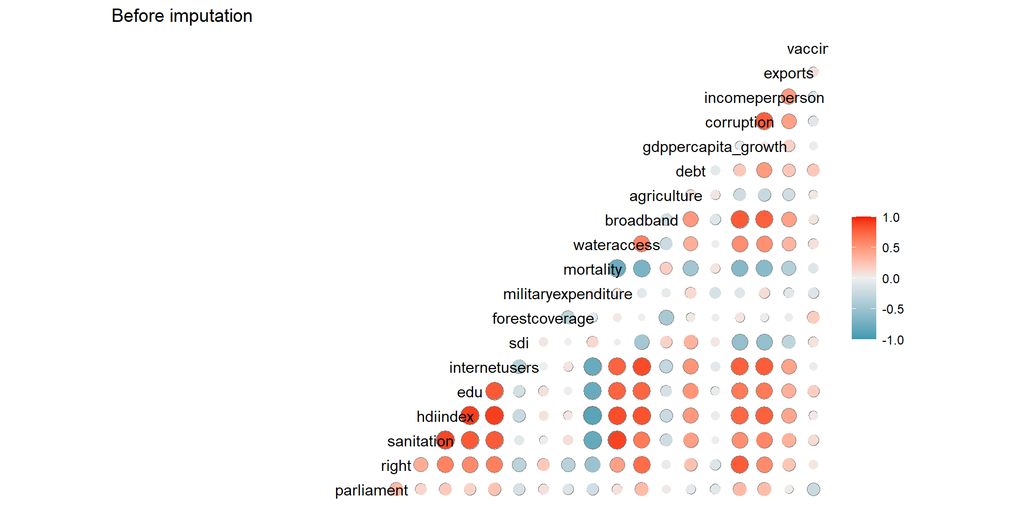

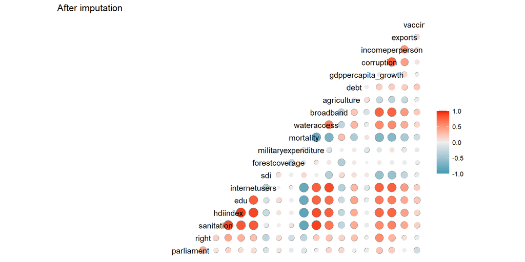

With knn imputation at k=10, the variable “right” is most affected, as its correlation with other variables was decreased from the imputation process. However, for reasons below, this will not be a problem.

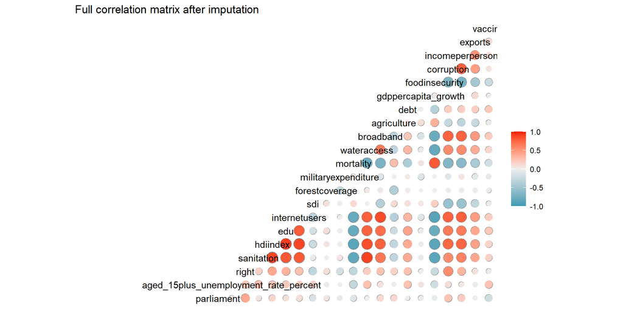

From the graph above, we see that the following variables are relatively uncorrelated from others: gdppercapita_growth,forestcoverage,sdi,aged_15plus_unemployment_rate_percent,parliament,vaccine.

## Using standard regression

1. We do a regression of the happiness score based on these uncorrelated features to determine those with a statistically significant effect on the target.
2. We do a PR decomposition of the remaining variables to eliminate the multicollinearity concerns, and use the PCs cumulatively accounting for more than 80% of the total target variance for a PCR regression.
3. We do a PCR regression using the identified PCs alongside the independent features above.
4. We select the most parsimonious model, and use 10-fold cross validation to achieve the best model.

#### Step 1

```r
lm_independent=lm(hapiscore_whr~gdppercapita_growth+forestcoverage+sdi+aged_15plus_unemployment_rate_percent+parliament+vaccine,data=df_variables_imputed)
summary(lm_independent)
```

```
##
## Call:
## lm(formula = hapiscore_whr ~ gdppercapita_growth + forestcoverage +
##     sdi + aged_15plus_unemployment_rate_percent + parliament +
##     vaccine, data = df_variables_imputed)
##
## Residuals:
##     Min      1Q  Median      3Q     Max
## -27.454  -8.212   1.149   8.695  22.503
##
## Coefficients:
##                                       Estimate Std. Error t value Pr(>|t|)
## (Intercept)                           57.59711    4.79909  12.002  < 2e-16 ***
## gdppercapita_growth                    0.09640    0.38718   0.249  0.80376
## forestcoverage                         0.06721    0.04676   1.437  0.15297
## sdi                                   -0.16974    0.05246  -3.236  0.00153 **
## aged_15plus_unemployment_rate_percent  0.25559    0.19967   1.280  0.20274
## parliament                             0.18249    0.09015   2.024  0.04491 *
## vaccine                               -0.25596    0.28752  -0.890  0.37493
## ---
## Signif. codes:  0 '***' 0.001 '**' 0.01 '*' 0.05 '.' 0.1 ' ' 1
##
## Residual standard error: 11.08 on 134 degrees of freedom
##   (100 observations deleted due to missingness)
## Multiple R-squared:  0.1384, Adjusted R-squared:  0.09984
## F-statistic: 3.588 on 6 and 134 DF,  p-value: 0.002493
```

Based on the model, sdi and parliament are viable uncorrelated features with a statistically significant effect on the target variable. We also check for multicollinearity in the model with VIF, and see that our assumption of independence of feature variables is correct.

```
##                   gdppercapita_growth                        forestcoverage
##                              1.007429                              1.060261
##                                   sdi aged_15plus_unemployment_rate_percent
##                              1.070614                              1.264849
##                            parliament                               vaccine
##                              1.130506                              1.277314
```

#### Step 2

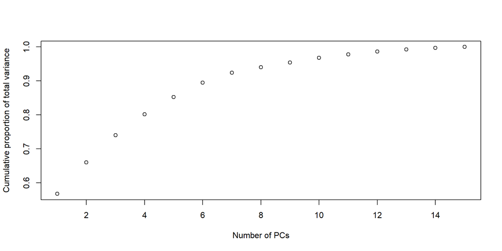

```r
pr_happiness=prcomp(df_variables_remaining,scale=T,center=T)
pr_var=pr_happiness$sdev^2
prop_var=pr_var/sum(pr_var)
plot(cumsum(prop_var),xlab="Number of PCs",ylab="Cumulative proportion of total variance")
```

We decide to use 4 PCs, which account for 80% of the total variance.

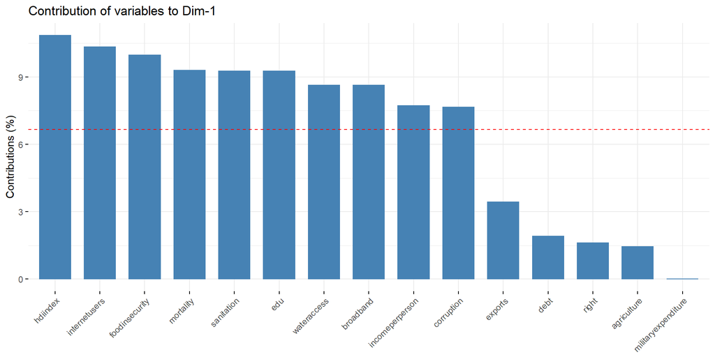

Restricting ourselves to the top 5 contributing variables to the first PC, we can argue that hdiindex, internetusers foodinsecurity,mortality and sanitation are top 5 variables that strongly explain the variance in the observations, and possible, the variance in the target variable.

#### Step 3

```r
pr_pc=pr_happiness$x[,1:4]
pr_pc=cbind(pr_pc,df_variables_imputed%>%dplyr::select(sdi,parliament))
pr_pc['hapiscore_whr']=df_variables$hapiscore_whr
# Pure PCR regression
model_pure_pcr=lm(hapiscore_whr~PC1+PC2+PC3+PC4,data=pr_pc)
# PCR + selected independent variables
model_pcr_additive=lm(hapiscore_whr~PC1+PC2+PC3+PC4+sdi+parliament,data=pr_pc)
summary(model_pcr_additive)
```

```
##
## Call:
## lm(formula = hapiscore_whr ~ PC1 + PC2 + PC3 + PC4 + sdi + parliament,
##     data = pr_pc)
##
## Residuals:
##     Min      1Q  Median      3Q     Max
## -13.168  -4.499  -0.345   3.963  18.421
##
## Coefficients:
##             Estimate Std. Error t value Pr(>|t|)
## (Intercept) 51.04591    2.63666  19.360   <2e-16 ***
## PC1          3.14720    0.20826  15.112   <2e-16 ***
## PC2          1.37137    0.59923   2.289   0.0237 *
## PC3          1.31562    0.55568   2.368   0.0193 *
## PC4         -0.13343    0.63877  -0.209   0.8349
## sdi          0.03694    0.04218   0.876   0.3827
## parliament   0.11642    0.05561   2.093   0.0382 *
## ---
## Signif. codes:  0 '***' 0.001 '**' 0.01 '*' 0.05 '.' 0.1 ' ' 1
##
## Residual standard error: 6.722 on 134 degrees of freedom
##   (100 observations deleted due to missingness)
## Multiple R-squared:  0.6831, Adjusted R-squared:  0.6689
## F-statistic: 48.15 on 6 and 134 DF,  p-value: < 2.2e-16
```

To see whether our independent features add any value to our PCR model, we conduct a model F-test using both. We see that the model with our independent variables along the PCs does not yield a better fit than the pure PCR model for parsimony, so the latter is preferred. In fact, we may only need 3 PCs rather than 4.

```r
anova(model_pure_pcr,model_pcr_additive,test="F")
```

```
## Analysis of Variance Table
##
## Model 1: hapiscore_whr ~ PC1 + PC2 + PC3 + PC4
## Model 2: hapiscore_whr ~ PC1 + PC2 + PC3 + PC4 + sdi + parliament
##   Res.Df    RSS Df Sum of Sq      F  Pr(>F)
## 1    136 6308.2
## 2    134 6055.1  2    253.07 2.8003 0.06435 .
## ---
## Signif. codes:  0 '***' 0.001 '**' 0.01 '*' 0.05 '.' 0.1 ' ' 1
```

We fit the most parsimonious model, which includes the first 3 PCs.

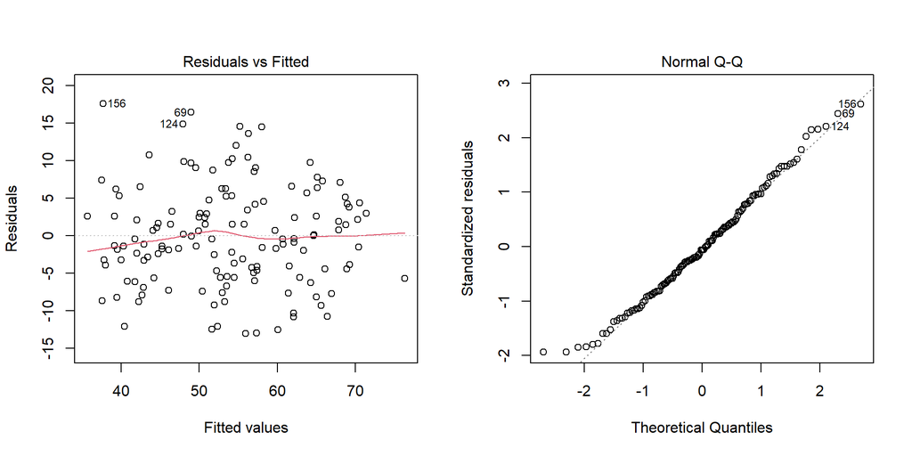

```r
model_3_pcr=lm(hapiscore_whr~PC1+PC2+PC3,data=pr_pc)
par(mfrow=c(1,2))
plot(model_pure_pcr,which=c(1))
plot(model_pure_pcr,which=c(2))
```

Based on the diagnostics plot above, while our residuals do follow a normal distribution, there seems to be less variability at higher levels of the fitted values/predicted happiness scores.

```r
# Constructing our 10-fold cross validation of the 3 PC regression
set.seed(123)
lm_model_final_cv=train(hapiscore_whr~PC1+PC2+PC3,
      method="lm",
      data=working_pc,
      trControl=trainControl(method="cv",number=10))
```

## Stepwise regression with 10-fold cross-validation

Stepwise regression allows us to choose the best model by AIC (Akaike Information Criterion), which measures how well a model fits the data that it was generated from. AIC is calculated based on the number of independent variables used to build the model, and the maximum likelihood estimate of the model. The best-fit model according to AIC is the one that is able to explain the greatest amount of variation using the fewest possible independent variables, and in statistical comparison, the smaller the AIC, the better the model fit. It effectively acts as a form of dimensionality reduction. Here, we combine it with 10-fold cross validation.

```r
train.control <- trainControl(method = "cv", number = 10)
res.lm <- lm(hapiscore_whr ~., data = df_variables_full)
# Train the model
set.seed(123)
step.model <- train(hapiscore_whr ~., data = df_variables_full,
                    method = "lmStepAIC",
                    trControl = train.control,
                    trace = FALSE
                    )
step.model$results
```

```
##   parameter    RMSE  Rsquared      MAE    RMSESD RsquaredSD     MAESD
## 1      none 6.95562 0.6715584 5.490028 0.9077281 0.08824584 0.8665663
```

```r
summary(step.model$finalModel)
```

```
##
## Call:
## lm(formula = .outcome ~ parliament + aged_15plus_unemployment_rate_percent +
##     sanitation + hdiindex + militaryexpenditure + debt + foodinsecurity +
##     incomeperperson + vaccine, data = dat)
##
## Residuals:
##      Min       1Q   Median       3Q      Max
## -13.6239  -3.1831  -0.1123   3.5026  14.3078
##
## Coefficients:
##                                         Estimate Std. Error t value Pr(>|t|)
## (Intercept)                            2.917e+01  6.559e+00   4.447 1.84e-05
## parliament                             8.846e-02  4.887e-02   1.810 0.072572
## aged_15plus_unemployment_rate_percent -4.077e-01  1.152e-01  -3.540 0.000555
## sanitation                             9.247e-02  4.401e-02   2.101 0.037545
## hdiindex                               3.319e+01  1.012e+01   3.281 0.001328
## militaryexpenditure                   -4.879e-01  3.023e-01  -1.614 0.109017
## debt                                  -2.188e-01  1.049e-01  -2.086 0.038892
## foodinsecurity                        -9.052e-02  5.536e-02  -1.635 0.104426
## incomeperperson                        9.875e-05  4.831e-05   2.044 0.042974
## vaccine                               -2.559e-01  1.538e-01  -1.664 0.098453
##
## (Intercept)                           ***
## parliament                            .
## aged_15plus_unemployment_rate_percent ***
## sanitation                            *
## hdiindex                              **
## militaryexpenditure
## debt                                  *
## foodinsecurity
## incomeperperson                       *
## vaccine                               .
## ---
## Signif. codes:  0 '***' 0.001 '**' 0.01 '*' 0.05 '.' 0.1 ' ' 1
##
## Residual standard error: 5.948 on 131 degrees of freedom
## Multiple R-squared:  0.7575, Adjusted R-squared:  0.7408
## F-statistic: 45.46 on 9 and 131 DF,  p-value: < 2.2e-16
```

```r
print("Model VIF:")
```

```
## [1] "Model VIF:"
```

```r
car::vif(step.model$finalModel)
```

```
##                            parliament aged_15plus_unemployment_rate_percent
##                              1.154077                              1.461196
##                            sanitation                              hdiindex
##                              6.855956                              9.691989
##                   militaryexpenditure                                  debt
##                              1.052972                              1.355133
##                        foodinsecurity                       incomeperperson
##                              4.928030                              3.107687
##                               vaccine
##                              1.268817
```

## Backward selection regression with 10-fold cross-validation

```r
set.seed(123)
# Set up repeated k-fold cross-validation
#Train the model
step.model1 <- train(hapiscore_whr ~parliament+aged_15plus_unemployment_rate_percent+right+sanitation+edu+internetusers+sdi+hdiindex+forestcoverage+
                       militaryexpenditure+mortality+wateraccess+broadband+agriculture+debt+gdppercapita_growth+foodinsecurity+
                       exports+corruption+vaccine+incomeperperson, data = df_variables_full,
                    method = "leapBackward",
                    trControl = train.control,
                    tuneGrid = data.frame(nvmax = 1:21))
step.model1$results
```

```
##    nvmax     RMSE  Rsquared      MAE    RMSESD RsquaredSD     MAESD
## 1      1 6.784375 0.6757597 5.548961 0.9486462 0.10791242 0.9140123
## 2      2 6.315380 0.7214717 5.126295 0.9515360 0.09356586 0.9350675
## 3      3 6.670790 0.6918227 5.384716 1.1325650 0.10563462 1.0926823
## 4      4 6.807280 0.6820000 5.508762 1.1152929 0.11458587 0.9850286
## 5      5 7.064836 0.6545043 5.566723 1.0465982 0.10275982 0.9755875
## 6      6 7.108393 0.6509712 5.645065 1.0394769 0.09956373 0.8934323
## 7      7 7.107698 0.6555437 5.603481 0.9933331 0.08552718 0.8051096
## 8      8 6.982381 0.6678099 5.549312 0.8718187 0.08273765 0.7819652
## 9      9 6.931535 0.6726290 5.509465 0.8704779 0.08619048 0.8682842
## 10    10 6.841701 0.6800570 5.421530 0.9314415 0.09529698 0.9458091
## 11    11 6.827031 0.6825009 5.390666 1.0282190 0.09229685 1.0058782
## 12    12 6.799391 0.6899656 5.363766 1.0558780 0.08708759 0.9619841
## 13    13 6.789388 0.6938756 5.344847 1.0603376 0.08467226 0.9507640
## 14    14 6.792690 0.6909069 5.349177 1.0598103 0.08556899 0.9001097
## 15    15 6.802590 0.6890182 5.370284 1.0530334 0.07895894 0.8643394
## 16    16 6.813984 0.6893303 5.383545 1.0277638 0.07442090 0.7981868
## 17    17 6.800794 0.6895234 5.368231 1.0356690 0.07617250 0.7860851
## 18    18 6.774503 0.6928399 5.367954 1.0291517 0.07436952 0.7896262
## 19    19 6.770243 0.6936579 5.362559 1.0455182 0.07507162 0.8014676
## 20    20 6.777820 0.6935106 5.378273 1.0459528 0.07484214 0.7970572
## 21    21 6.781860 0.6933557 5.382438 1.0432164 0.07457562 0.7943467
```

```r
step.model1$bestTune
```

```
##   nvmax
## 2     2
```

```r
#summary(step.model1$finalModel)
model.lm2 <- lm(hapiscore_whr~aged_15plus_unemployment_rate_percent+hdiindex, data=df_variables_full)
summary(model.lm2)
```

```
##
## Call:
## lm(formula = hapiscore_whr ~ aged_15plus_unemployment_rate_percent +
##     hdiindex, data = df_variables_full)
##
## Residuals:
##      Min       1Q   Median       3Q      Max
## -16.1678  -4.0871  -0.4677   4.7841  14.9406
##
## Coefficients:
##                                       Estimate Std. Error t value Pr(>|t|)
## (Intercept)                             9.7154     2.5621   3.792 0.000223 ***
## aged_15plus_unemployment_rate_percent  -0.5002     0.1080  -4.630 8.37e-06 ***
## hdiindex                               66.5974     3.6852  18.072  < 2e-16 ***
## ---
## Signif. codes:  0 '***' 0.001 '**' 0.01 '*' 0.05 '.' 0.1 ' ' 1
##
## Residual standard error: 6.405 on 138 degrees of freedom
## Multiple R-squared:  0.7037, Adjusted R-squared:  0.6994
## F-statistic: 163.9 on 2 and 138 DF,  p-value: < 2.2e-16
```

```r
print("Model VIF:")
```

```
## [1] "Model VIF:"
```

```r
car::vif(model.lm2)
```

```
## aged_15plus_unemployment_rate_percent                              hdiindex
##                              1.109005                              1.109005
```

## Model comparisons

```r
model_name=c("CV 3 PCR","CV StepAIC","CV Backward selection")
adj_r_squared=c(summary(lm_model_final_cv)$adj.r.squared,summary(step.model$finalModel)$adj.r.squared,summary(model.lm2)$adj.r.squared)
rmse_model=c(RMSE(fitted(lm_model_final_cv),df_variables_full$hapiscore_whr),
             RMSE(fitted(step.model$finalModel),df_variables_full$hapiscore_whr),
             RMSE(fitted(model.lm2),df_variables_full$hapiscore_whr))
```

```r
final_compare=data.frame(model_name=model_name,adj_r_squared=adj_r_squared,rmse=rmse_model)
final_compare%>%pivot_longer(c("adj_r_squared","rmse"))%>%pivot_wider(names_from=model_name,values_from=value)
```

```
## # A tibble: 2 x 4
##   name          `CV 3 PCR` `CV StepAIC` `CV Backward selection`
##   <chr>              <dbl>        <dbl>                   <dbl>
## 1 adj_r_squared      0.663        0.741                   0.699
## 2 rmse               6.69         5.73                    6.34
```

## Summary

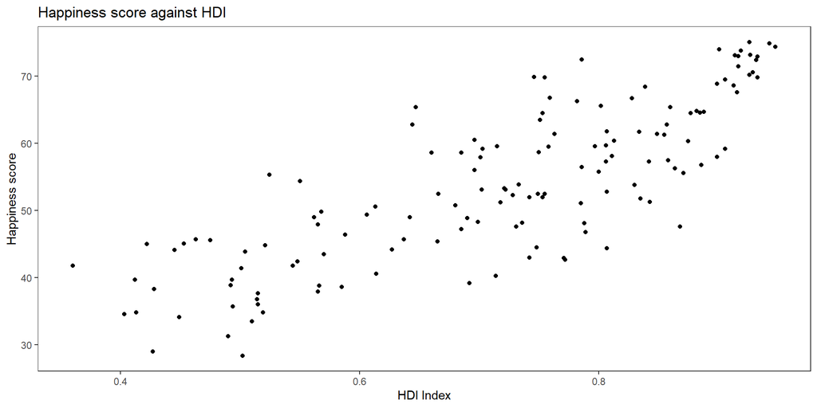